# Machine Learning Project

Rafael Daniel

3 de abril de 2017

# Project goal

The goal of this project is to use data from accelerometers on the belt, forearm, arm, and dumbell of 6 participants who were asked to perform barbell lifts correctly and incorrectly in 5 different ways to develope a model that can predict when this exercice is done correctly. Once the model is defined with the train set, the 20 cases of the test set will be used to test the model.

# Data Source

The data for this project come from this source: http://groupware.les.inf.puc-rio.br/har.

The training data for this project are available here: https://d396qusza40orc.cloudfront.net/predmachlearn/pml-training.csv

The test data are available here: https://d396qusza40orc.cloudfront.net/predmachlearn/pml-testing.csv

```r
# load train and test sets from the website
train<-read.csv("https://d396qusza40orc.cloudfront.net/predmachlearn/pml-training.csv")
classe<-train$classe

test<-read.csv("https://d396qusza40orc.cloudfront.net/predmachlearn/pml-testing.csv")
```

# Clean and select features

1. From the train set the features that contain NA values are removed

```r
isna<-colSums(is.na(train))
# the following 63 features contain NA values and are removed
print("NA containing fetatures:")
```

```
## [1] "NA containing fetatures:"
```

```r
names(train[isna!=0])
```

```
##  [1] "max_roll_belt"            "max_picth_belt"
##  [3] "min_roll_belt"            "min_pitch_belt"
##  [5] "amplitude_roll_belt"      "amplitude_pitch_belt"
##  [7] "var_total_accel_belt"     "avg_roll_belt"
##  [9] "stddev_roll_belt"         "var_roll_belt"
## [11] "avg_pitch_belt"           "stddev_pitch_belt"
## [13] "var_pitch_belt"           "avg_yaw_belt"
## [15] "stddev_yaw_belt"          "var_yaw_belt"
## [17] "var_accel_arm"            "avg_roll_arm"
## [19] "stddev_roll_arm"          "var_roll_arm"
## [21] "avg_pitch_arm"            "stddev_pitch_arm"
## [23] "var_pitch_arm"            "avg_yaw_arm"
## [25] "stddev_yaw_arm"           "var_yaw_arm"
## [27] "max_roll_arm"             "max_picth_arm"
## [29] "max_yaw_arm"              "min_roll_arm"
```

[output cut: 19 more lines]

```r
train<-train[-isna==0]
```

2. From the remaining features there are factor variables that are actually numbers that were converted into factor as contain “#?DIV/0!” values, these features are removed from the training set.

```r
# factor observables

train<-train[-which(sapply(train, is.factor))]
```

3. All the features not relate with one of the devices are also removed from the set

```r
# select observables related with the devices
belt_var<-grep(pattern = "_belt",x = names(train),value = T)
arm_var<-grep(pattern = "_arm",x = names(train),value = T)
farm_var<-grep(pattern = "_forearm",x = names(train),value = T)
dum_var<-grep(pattern = "_dumbbell",x = names(train),value = T)

train<-train[c(belt_var,arm_var,farm_var,dum_var)]
train$classe<-classe
```

4. At this point the 159 features are now reduced to the following 52 features.

```r
names(train)
```

[output not shown]

# Data visualization

The following plots show a general idea of the data relationship for each device, nothing can be concluded from these plots.

```r
library(caret)
```

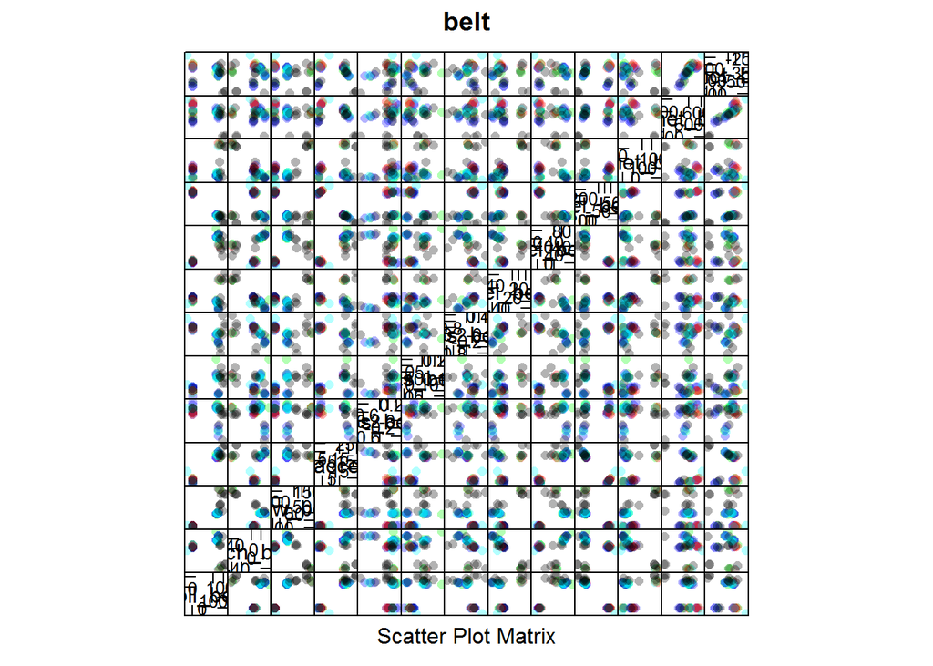

```r
set.seed(123)
#sample 50 points of the training set
sdata<-train[sample(1:19622,50),]

featurePlot(x=sdata[,belt_var],y=sdata$classe,plot = "pairs", col=c("green","blue","red","cyan","black"), fill=c("green","blue","red","cyan","grey"),alpha=0.3,pch=c(16,16,16,16,16), main="belt")
```

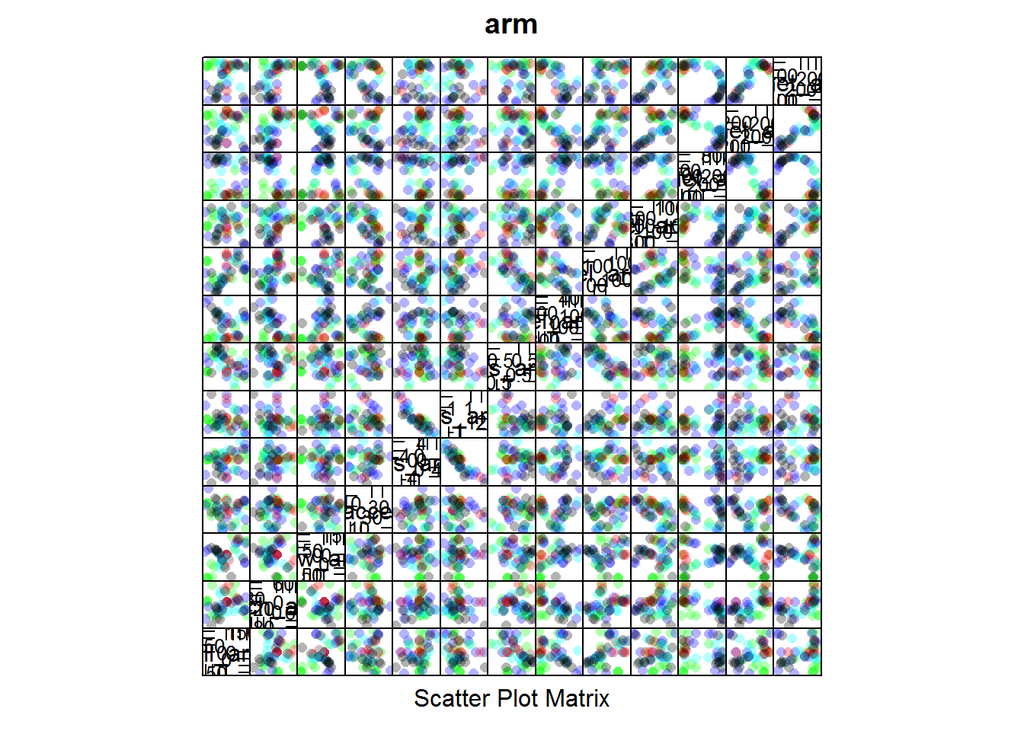

```r
featurePlot(x=sdata[,arm_var],y=sdata$classe,plot = "pairs", col=c("green","blue","red","cyan","black"), fill=c("green","blue","red","cyan","grey"),alpha=0.3,pch=c(16,16,16,16,16), main="arm")
```

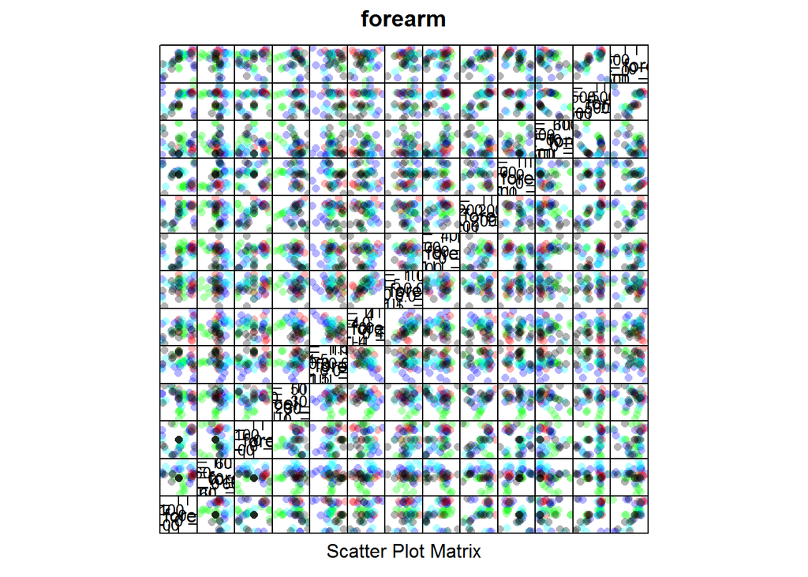

```r
featurePlot(x=sdata[,farm_var],y=sdata$classe,plot = "pairs", col=c("green","blue","red","cyan","black"), fill=c("green","blue","red","cyan","grey"),alpha=0.3,pch=c(16,16,16,16,16), main="forearm")
```

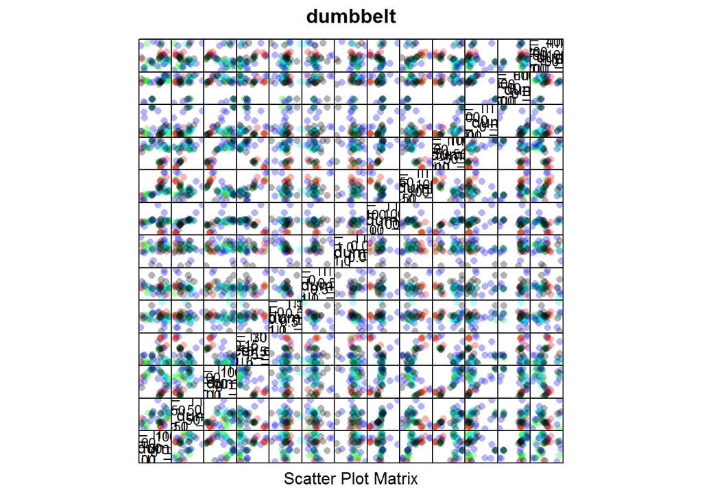

```r
featurePlot(x=sdata[,dum_var],y=sdata$classe,plot = "pairs", col=c("green","blue","red","cyan","black"), fill=c("green","blue","red","cyan","grey"),alpha=0.3,pch=c(16,16,16,16,16), main="dumbbelt")
```

# Model selection

To get a more accurate model estimate 10 fod cross validation will be used in all the models. Accuracy will be used to measure the model fit in all cases.

```r
control<-trainControl(method="cv", number=10)
metric<-"Accuracy"
```

```r
use_md<-c("rpart","knn")
devices<-list(belt=belt_var,arm=arm_var,farm=farm_var,dum=dum_var)

adj_md_dv<-list()

for (d in 1:4){
  #subset train data for the selelected device
  data<-train[devices[[d]]]
  data$classe<-classe
  #print (names(devices)[d]) this allows to control which device is being computed

  for (i in use_md){
      #calculate each model for the selected device
      #print(paste("Model:",i)) this allows to control which model is being computed

      set.seed(123)
      lbl<-paste(names(devices)[d],i)
      adj_md_dv[[lbl]]<-train(classe~.,method=i,data=data,trControl=control, metric=metric)
  }
}

summary(resamples(adj_md_dv))
```

```
##
## Call:
## summary.resamples(object = resamples(adj_md_dv))
##
## Models: belt rpart, belt knn, arm rpart, arm knn, farm rpart, farm knn, dum rpart, dum knn
## Number of resamples: 10
##
## Accuracy
##              Min. 1st Qu. Median   Mean 3rd Qu.   Max. NA's
## belt rpart 0.3775  0.3949 0.4485 0.4746  0.5658 0.5879    0
## belt knn   0.7054  0.7151 0.7223 0.7209  0.7287 0.7307    0
## arm rpart  0.3201  0.3415 0.3567 0.3531  0.3668 0.3707    0
## arm knn    0.7222  0.7377 0.7402 0.7415  0.7502 0.7533    0
## farm rpart 0.3702  0.3815 0.3925 0.3939  0.4059 0.4159    0
## farm knn   0.7561  0.7728 0.7778 0.7763  0.7819 0.7849    0
## dum rpart  0.3804  0.3839 0.4065 0.4089  0.4324 0.4419    0
## dum knn    0.8298  0.8318 0.8359 0.8371  0.8417 0.8502    0
##
## Kappa
##              Min. 1st Qu. Median   Mean 3rd Qu.   Max. NA's
## belt rpart 0.1437  0.1700 0.2596 0.2972  0.4413 0.4727    0
## belt knn   0.6260  0.6380 0.6470 0.6455  0.6557 0.6583    0
## arm rpart  0.1362  0.1595 0.1813 0.1746  0.1896 0.1943    0
## arm knn    0.6487  0.6680 0.6717 0.6731  0.6842 0.6885    0
## farm rpart 0.1862  0.1978 0.2115 0.2143  0.2314 0.2421    0
## farm knn   0.6913  0.7125 0.7188 0.7168  0.7238 0.7279    0
## dum rpart  0.1642  0.1690 0.2095 0.2125  0.2541 0.2664    0
## dum knn    0.7845  0.7868 0.7921 0.7937  0.7994 0.8101    0
```

```r
use_md<-c("rpart","knn")
mnames<-c("^gyros_","^magnet_","^roll_","^pitch_","^yaw_","^accel_","^total_accel_")

measures<-lapply(X = mnames,FUN = function(namepattern) grep(pattern = namepattern,x = names(train),value = T) )

adj_md_meas<-list()

for (d in 1:7){
  #subset train data for the selelected measure
  data<-train[measures[[d]]]
  data$classe<-classe
  #print (d) this allows to control which device is being computed

  for (i in use_md){
      #calculate each model for the selected device
      #print(paste("Model:",i)) this allows to control which model is being computed

      set.seed(123)
      lbl<-paste(d,i)
      adj_md_meas[[lbl]]<-train(classe~.,method=i,data=data,trControl=control, metric=metric)
  }
}

summary(resamples(adj_md_meas))
```

```
##
## Call:
## summary.resamples(object = resamples(adj_md_meas))
##
## Models: 1 rpart, 1 knn, 2 rpart, 2 knn, 3 rpart, 3 knn, 4 rpart, 4 knn, 5 rpart, 5 knn, 6 rpart, 6 knn, 7 rpart, 7 knn
## Number of resamples: 10
##
## Accuracy
##           Min. 1st Qu. Median   Mean 3rd Qu.   Max. NA's
## 1 rpart 0.3981  0.4048 0.4098 0.4087  0.4142 0.4180    0
## 1 knn   0.7823  0.7878 0.7948 0.7947  0.8014 0.8055    0
## 2 rpart 0.3663  0.4136 0.4538 0.4354  0.4604 0.4699    0
## 2 knn   0.8655  0.8708 0.8731 0.8750  0.8772 0.8940    0
## 3 rpart 0.4213  0.4304 0.4390 0.4366  0.4417 0.4503    0
## 3 knn   0.8195  0.8224 0.8327 0.8317  0.8375 0.8507    0
```

[output cut: 25 more lines]

```r
data<-train[c(measures[[1]],measures[[2]],measures[[6]])]
data$classe<-classe

set.seed(123)
select_md_meas<-train(classe~.,method="knn",data=data,trControl=control, metric=metric)
print(select_md_meas)
```

```
## k-Nearest Neighbors
##
## 19622 samples
##    36 predictor
##     5 classes: 'A', 'B', 'C', 'D', 'E'
##
## No pre-processing
## Resampling: Cross-Validated (10 fold)
## Summary of sample sizes: 17660, 17661, 17659, 17660, 17658, 17660, ...
## Resampling results across tuning parameters:
##
##   k  Accuracy   Kappa
##   5  0.9115795  0.8880040
##   7  0.8887982  0.8591024
##   9  0.8710635  0.8365557
##
## Accuracy was used to select the optimal model using  the largest value.
## The final value used for the model was k = 5.
```

```r
pred.test<-predict(select_md_meas,test)
```

# Prediction

```r
pred.test
```

```
##  [1] B A B A A E D B A A B C B A E E A B B B
## Levels: A B C D E
```

```r
write.csv(file="prediction.csv",x = pred.test)
```